# Geometric Nearest Neighbors Examples

Anton Antonov

`2022-10-31`

```r
library(magrittr)
library(dplyr)
library(purrr)
library(Matrix)
library(ggplot2)
library(OutlierIdentifiers)
library(GNNMon)
```

# Introduction

The primary motivation for making this Geometric Nearest Neighbors (GNN) software monad (`GNNMon`) is the implementation of a simple Nearest Neighbors (NN’s) classifier that tells does a point belong to a set of points.

That classification functionality can be also used to find outliers in a set points.

The rest of the sections show a complete, step-by-step example of using `GNNMon`.

The R-package [`GNNMon-R`](https://github.com/antononcube/R-packages/tree/master/GNNMon-R), [AAp1], provides implementation of `GNNMon`. That package uses the outlier identifiers package [`OutlierIdentifiers`](https://github.com/antononcube/R-packages/tree/master/OutlierIdentifiers), [AAp2].

# Data

Here we generate random 2D points (a matrix with two columns):

```r
set.seed(234)
data <- matrix( c( rnorm( n = 30, mean = 0, sd = 5 ), rnorm( n = 30, mean = 12, sd = 3) ), ncol = 2 )
colnames(data) <- c("X", "Y")
#rownames(data) <- paste0("p", formatC(1:nrow(data), digits = 2, flag = "0"))
data
```

```
                 X         Y
 [1,]   3.30384868 10.989955
 [2,] -10.26491502 10.022232
 [3,]  -7.49603026 11.697699
 [4,]   7.35616558 14.111724
 [5,]   7.29569264 13.314165
 [6,]   0.70069518 16.491444
 [7,]   1.04592197 12.648733
 [8,] -15.18044912  7.513986
 [9,]  -2.43467066 12.374982
[10,]  -5.43933654  8.885717
[11,]   0.28929853 12.661268
[12,]   5.51987751 10.685743
[13,]  -0.12808483 16.435913
[14,]   2.57423197 10.331060
```

[output cut: 16 more lines]

# Monad object

Here using `GNNMon` we do the following steps:

1. Make `GNNMon` object (i.e. lift the data into the monad)
2. For each point compute the Nearest Neighbors (NNs) distances
3. For each point compute statistics over its NNs distances, and derive the lower and upper proximity thresholds
4. Show the results

```r
gnnObj <-
  GNNMonUnit( data ) %>%
  GNNMonComputeNearestNeighborDistances( nTopNNs = 3, method = "euclidean" ) %>%
  GNNMonComputeThresholds( nnsRadiusFunction = mean, thresholdsIdentifier = HampelIdentifierParameters ) %>%
  GNNMonEchoValue
```

| SearchIndex | Radius | Mean | SD |
| --- | --- | --- | --- |
| 1 | 0.9840893 | 0.9840893 | 0.314099432 |
| 2 | 3.3363165 | 3.3363165 | 0.194487674 |
| 3 | 2.4236463 | 2.4236463 | 0.429877901 |
| 4 | 2.5620668 | 2.5620668 | 1.589371285 |
| 5 | 2.3190106 | 2.3190106 | 1.318950983 |
| 6 | 1.5278144 | 1.5278144 | 0.679099840 |
| 7 | 0.9500987 | 0.9500987 | 0.282395108 |
| 8 | 7.4920416 | 7.4920416 | 1.709528650 |
| 9 | 2.7337268 | 2.7337268 | 0.015303080 |
| 10 | 1.3534420 | 1.3534420 | 0.541773675 |

[output cut: 20 more lines]

# Which member of the set do not belong to it?

If we call `GNNMonClassify` without points argument then monad’s object data points are used:

```r
gnnObj <- gnnObj %>% GNNMonClassify()
```

Here is monad’s object value:

```r
gnnObj %>% GNNMonTakeValue
```

| Index | Radius | Label |
| --- | --- | --- |
| 1 | 0.5511951 | TRUE |
| 2 | 2.1494976 | FALSE |
| 3 | 1.5290449 | TRUE |
| 4 | 1.2663774 | TRUE |
| 5 | 1.2616489 | TRUE |
| 6 | 0.7987259 | TRUE |
| 7 | 0.5253765 | TRUE |
| 8 | 4.6536629 | FALSE |
| 9 | 1.8184876 | TRUE |
| 10 | 0.7300709 | TRUE |

[output cut: 20 more lines]

Here we plot monad’s object points and color them according the classification result:

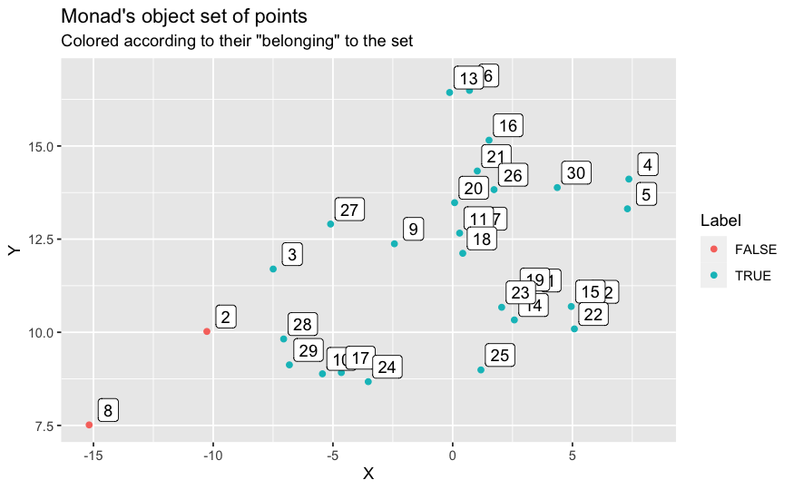

```r
ggplot( cbind( gnnObj %>% GNNMonTakeData, gnnObj %>% GNNMonTakeValue ) ) +
  geom_point( aes( x = X, y = Y, color = Label ) ) +
  geom_label( aes(x = X, y = Y, label = Index), nudge_x = 0.8, nudge_y = 0.4) +
  ggtitle( label = "Monad's object set of points", subtitle = "Colored according to their \"belonging\" to the set")
```

# Nearest neighbors for new, “external” points

Here we make a data frame with two new points:

```r
dfPoints <- data.frame( X = c(-6,2), Y = c(4.5,16) )
dfPoints
```

| X | Y |
| --- | --- |
| -6 | 4.5 |
| 2 | 16.0 |

Here we plot the original data with flags showing points indexes and the new data points colored in red:

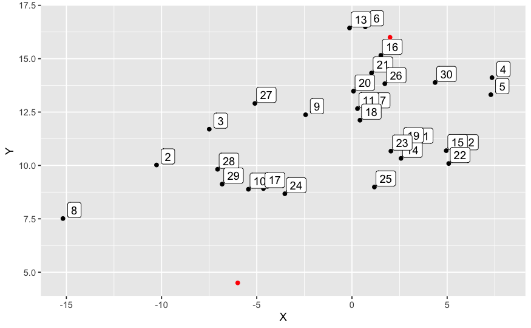

```r
qDF <- cbind( as.data.frame(data), Index = 1:nrow(data) )
ggplot(qDF) +
  geom_point( aes( x = X, y = Y ) ) +
  geom_label( aes( x = X, y = Y, label = Index), nudge_x = 0.6, nudge_y = 0.4) +
  geom_point( data = dfPoints, aes( x = X , y = Y), color = "red" )
```

Here we find the top 3 NNs for the second of new points:

```r
gnnObj %>%
  GNNMonFindNearest( point = as.numeric(dfPoints[2,]), 3 ) %>%
  GNNMonTakeValue
```

|  | Index | Distance |
| --- | --- | --- |
| p016 | 16 | 0.9725275 |
| p006 | 6 | 1.3891400 |
| p021 | 21 | 1.9340923 |

# Classification

Here we classify the two new points and a point monad’s object into TRUE and FALSE according to are they considered to belong to the set points in the monad object:

```r
gnnObj %>%
  GNNMonClassify( points = rbind( dfPoints, data[8,] ) ) %>%
  GNNMonTakeValue
```

| Index | Radius | Label |
| --- | --- | --- |
| 1 | 4.579580 | FALSE |
| 2 | 1.431920 | TRUE |
| 3 | 4.653663 | FALSE |

(Compare the result above with the plot above.)

# Proximity matrix

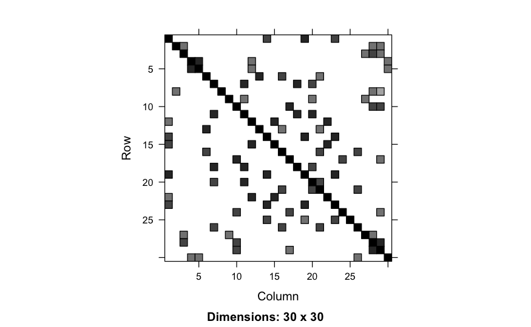

```r
matProx <-
  gnnObj %>%
  GNNMonComputeProximityMatrix() %>%
  GNNMonTakeValue

Matrix::image(matProx)
```

# References

[AAp1] Anton Antonov, [Geometric Nearest Neighbors Monad R-package](https://github.com/antononcube/R-packages/tree/master/GNNMon-R), (2019), [R-packages at GitHub/antononcube](https://github.com/antononcube/R-packages).

[AAp2] Anton Antonov, [Outlier Identifiers R-package](https://github.com/antononcube/R-packages/tree/master/OutlierIdentifiers), (2019), [R-packages at GitHub/antononcube](https://github.com/antononcube/R-packages).